# DATA624 Project-1

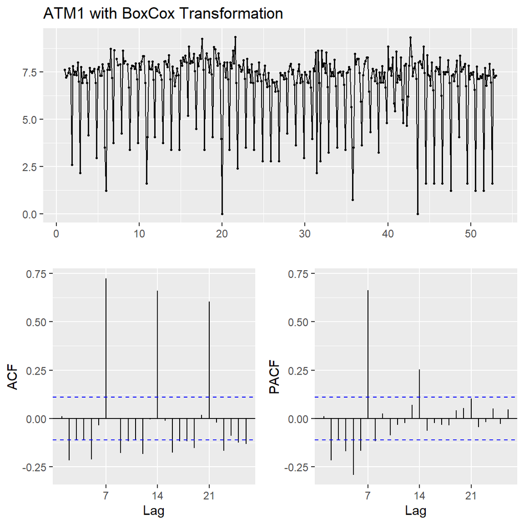

```r
atm1_bc <- BoxCox(atm1, lambda = BoxCox.lambda(atm1))
ggtsdisplay(atm1_bc, main="ATM1 with BoxCox Transformation")
```

After applying Box-Cox transformation, we still see the weekly seasonality in the timeseries. Differencing is needed.

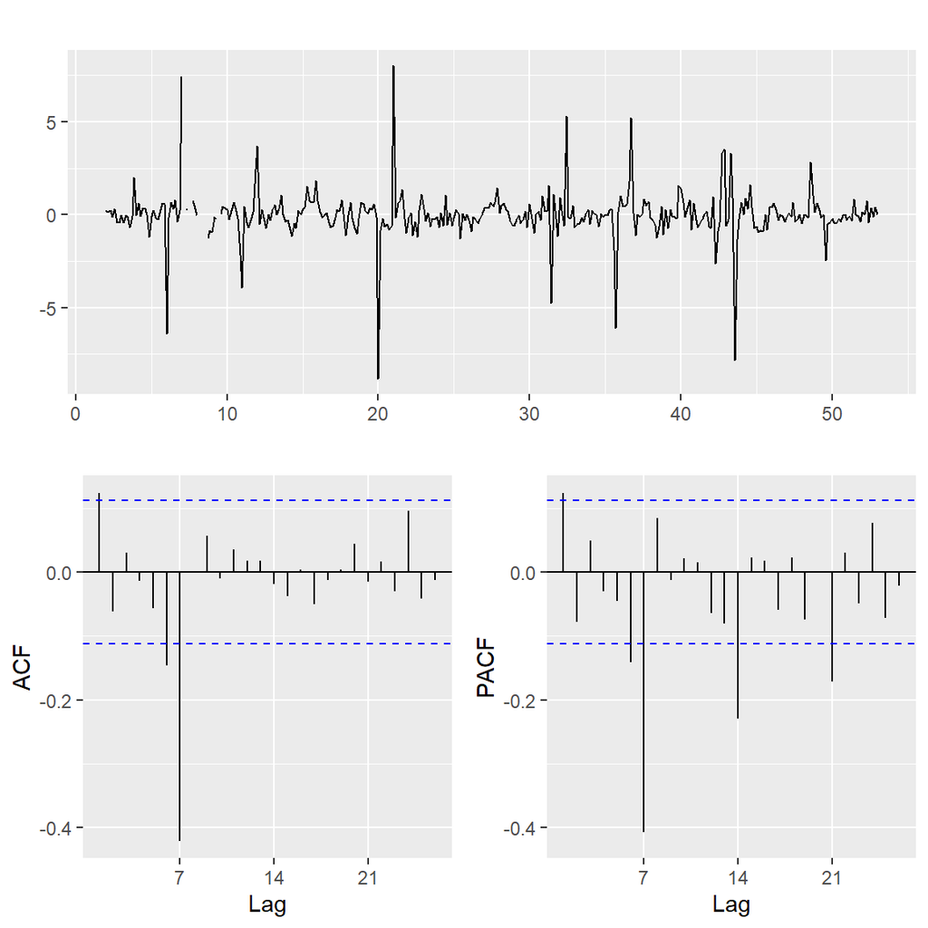

```r
ggtsdisplay(diff(atm1_bc, 7), points=FALSE)
```

```r
atm1_bc %>% diff(.,7) %>% ur.kpss() %>% summary()
```

```
##
## #######################
## # KPSS Unit Root Test #
## #######################
##
## Test is of type: mu with 5 lags.
##
## Value of test-statistic is: 0.016
##
## Critical value for a significance level of:
##                 10pct  5pct 2.5pct  1pct
## critical values 0.347 0.463  0.574 0.739
```

The timeseries now appears to be stationary. ARIMA(p,d,q)(P,D,Q)[m] model has p/P as order of the autoregressive part, d/D as degree of first differencing involved, q/Q as order of the moving average part, and m as number of observations. The non-seasonal significant lag1 in ACF and PACF suggest non-seasonal p=q=1.

```r
atm1_arima <- Arima(atm1, order=c(1,0,1), seasonal=c(0,1,1), lambda = BoxCox.lambda(atm1))
summary(atm1_arima)
```

```
## Series: atm1
## ARIMA(1,0,1)(0,1,1)[7]
## Box Cox transformation: lambda= 0.2081476
##
## Coefficients:
##           ar1     ma1     sma1
##       -0.5040  0.6201  -0.6438
## s.e.   0.2417  0.2183   0.0427
##
## sigma^2 = 1.252:  log likelihood = -544.29
## AIC=1096.58   AICc=1096.7   BIC=1112.11
##
## Training set error measures:
##                    ME     RMSE      MAE       MPE     MAPE      MASE
## Training set 2.514774 25.09103 15.83582 -89.65246 108.6821 0.8958869
##                      ACF1
## Training set -0.007347018
```

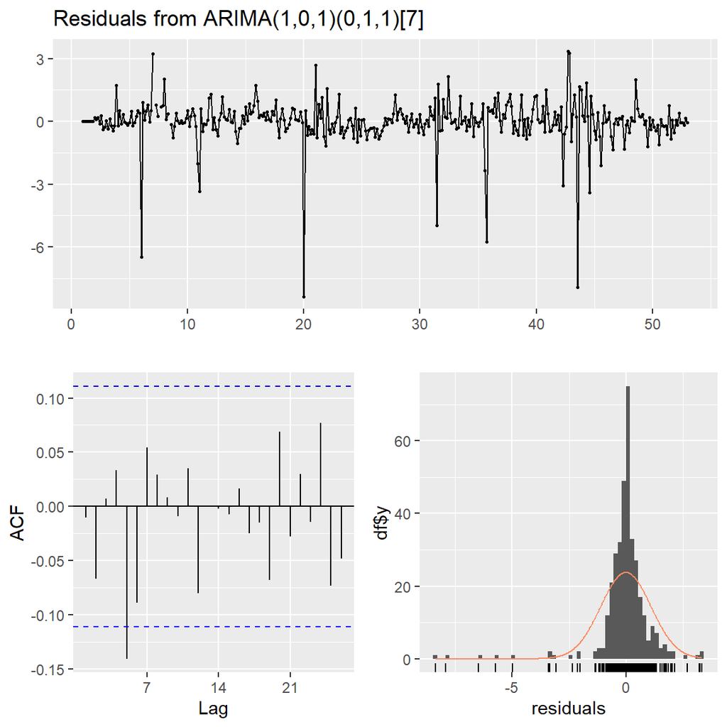

```
##
##  Ljung-Box test
##
## data:  Residuals from ARIMA(1,0,1)(0,1,1)[7]
## Q* = 9.4438, df = 11, p-value = 0.581
##
## Model df: 3.   Total lags used: 14
```

```r
checkresiduals(atm1_arima)
```

Now, let’s use auto.arima to find out which is the best Arima model:

```r
atm1_auto <- auto.arima(atm1, approximation = FALSE, lambda=BoxCox.lambda(atm1))
summary(atm1_auto)
```

```
## Series: atm1
## ARIMA(0,0,2)(0,1,1)[7]
## Box Cox transformation: lambda= 0.2081476
##
## Coefficients:
##          ma1      ma2     sma1
##       0.0989  -0.1107  -0.6482
## s.e.  0.0532   0.0527   0.0425
##
## sigma^2 = 1.247:  log likelihood = -543.68
## AIC=1095.37   AICc=1095.48   BIC=1110.89
##
## Training set error measures:
##                    ME     RMSE      MAE       MPE     MAPE      MASE       ACF1
## Training set 2.493867 25.19797 16.12913 -88.12706 107.3975 0.9124807 0.01895515
```

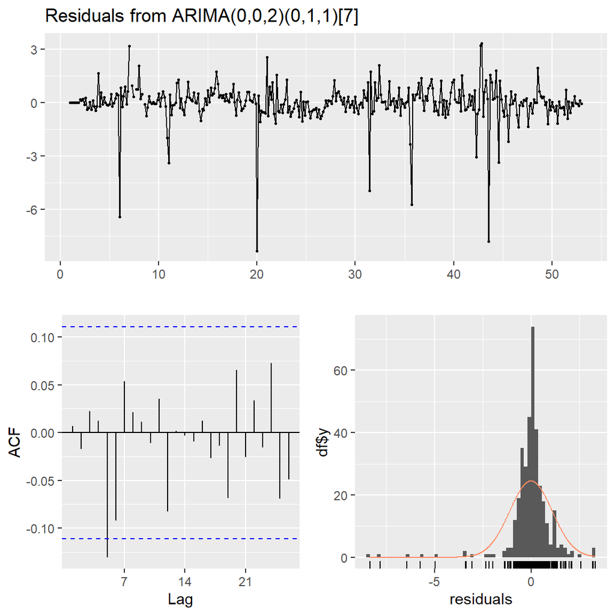

```
##
##  Ljung-Box test
##
## data:  Residuals from ARIMA(0,0,2)(0,1,1)[7]
## Q* = 8.5811, df = 11, p-value = 0.6605
##
## Model df: 3.   Total lags used: 14
```

```r
checkresiduals(atm1_auto)
```

The ARIMA model found by ‘auto.arima’ is ARIMA(0,0,2)(0,1,1)[7]. The ARIMA model I suggested is ARIMA(1,0,1)(0,1,1)[7].

According to the error measures and the residual plots, both models represents the data well with similar AIC values, similar error measures, and similar p-values. Both models can be applied, but the best Arima model is ARIMA(0,0,2)(0,1,1)[7], because it has a smaller AICc.

```r
atm1_model <- Arima(atm1, order=c(0,0,2), seasonal=c(0,1,1), lambda = BoxCox.lambda(atm1))
```